# Soccer Analytics: Key Figures by Stage

Results come from the pipeline (`targets::tar_make()` in the project root); this report only reads and plots them. Each figure is also saved as a PNG in `figures/` (in the project root) for slides. The Understat figures (stage 0) live in the earlier `tweedie_fit.Rmd` and `nbg_fit.Rmd`.

```r
library(targets)
library(dplyr)
library(ggplot2)
tar_source()
```

```r
team_match <- tar_read(team_match)
stage1 <- tar_read(stage1)
shots <- tar_read(shots)
```

# Stage 1: team level

**1.1 Team attacking profiles.** Each point is a team’s season. Teams reach their xG through volume, quality, or both.

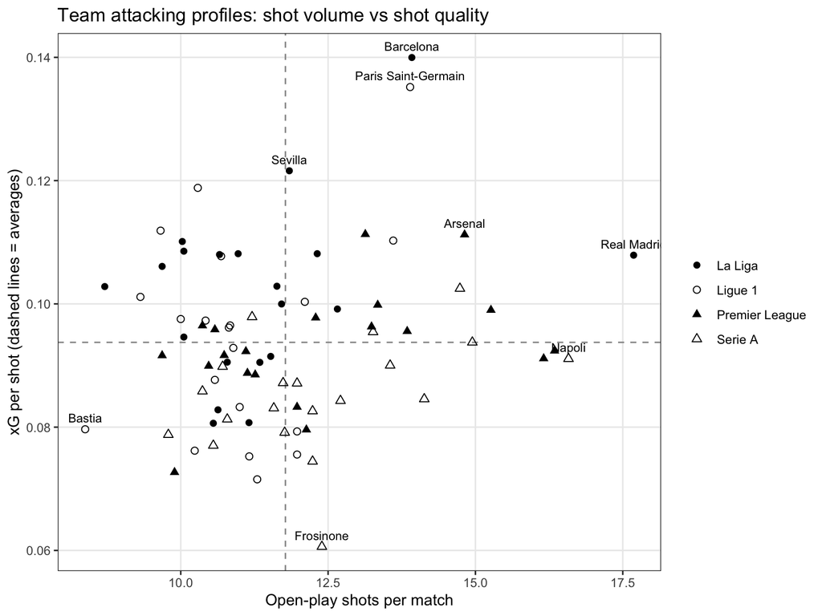

```r
save_fig(plot_team_profiles(team_match), "1-1_team_profiles", 8, 6)
```

**1.2 Five estimates of the Tweedie index.** If team xG were a single compound Poisson-gamma, these would agree.

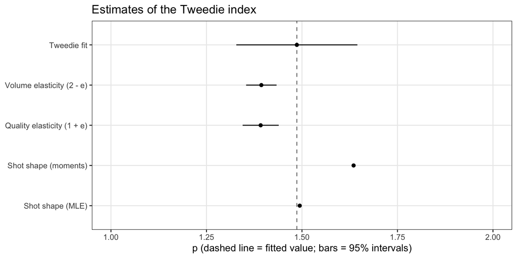

```r
save_fig(plot_p_compare(stage1), "1-2_p_compare", 8, 4)
```

```r
show_table(p_compare_table(stage1))
```

| Estimate | p | 95% interval | Gap from fitted p (in fitted-p SEs) |
| --- | --- | --- | --- |
| Tweedie fit | 1.487 | 1.328 to 1.645 | 0.0 |
| Volume elasticity (2 - e) | 1.394 | 1.354 to 1.433 | -1.1 |
| Quality elasticity (1 + e) | 1.392 | 1.345 to 1.439 | -1.2 |
| Shot shape (moments) | 1.635 | - | 1.8 |
| Shot shape (MLE) | 1.494 | - | 0.1 |

**1.3 Calibration of the two-part model.** Predicted shots x predicted quality against actual team-match xG; decile means on the diagonal mean calibrated.

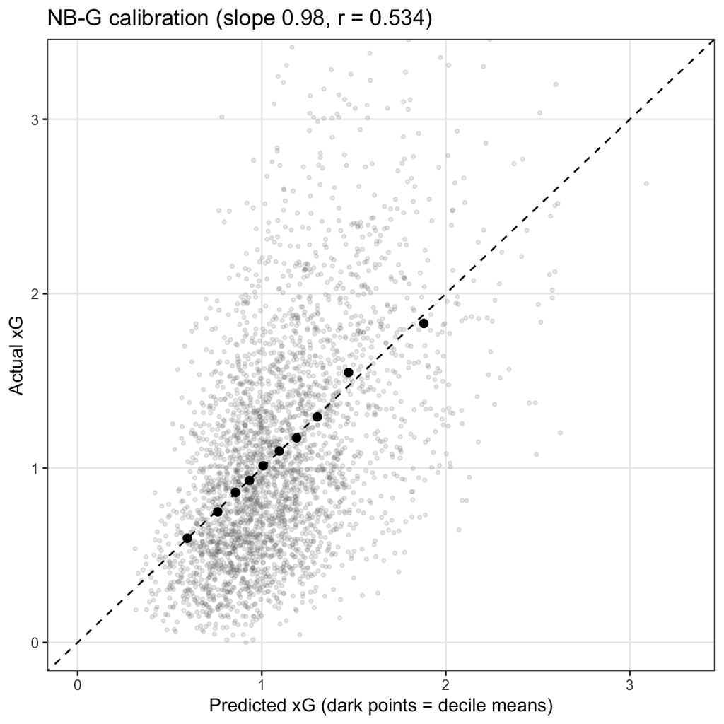

```r
save_fig(plot_calibration(team_match, stage1$pred_nbg, stage1$cal_nbg), "1-3_calibration", 6, 6)
```

**1.4 Why only open-play shots.** Goal rate against mean xG within xG deciles. Direct free kicks sit above the diagonal: StatsBomb’s xG underrates them.

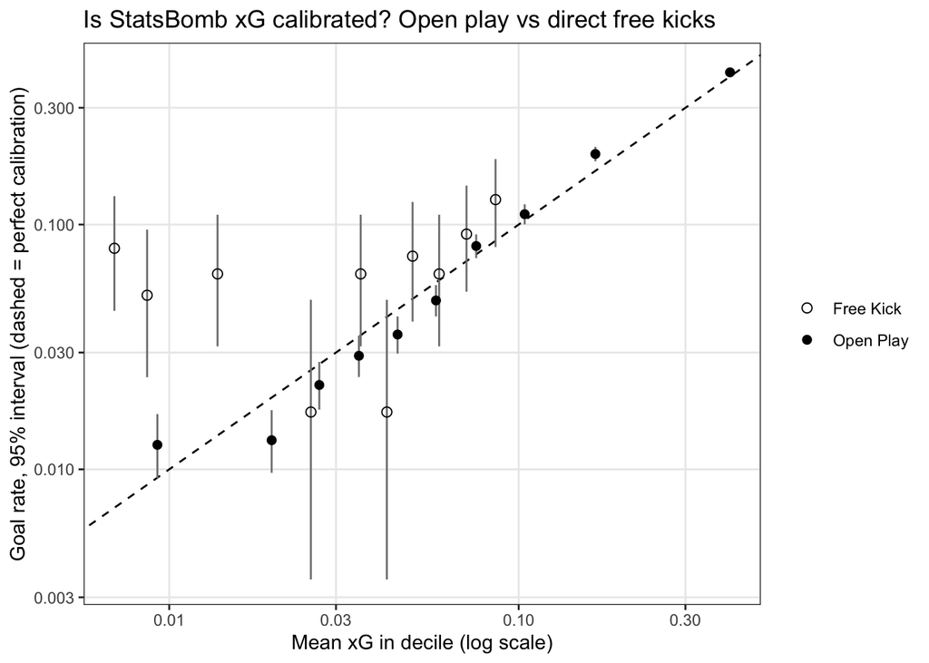

```r
save_fig(plot_xg_reliability(tar_read(shots_all)), "1-4_xg_calibration_by_type", 7, 5)
```

# Stage 1: shot quality

**1.5 Distribution of xG per shot.** The three-component mixture (solid) and its components (dashed).

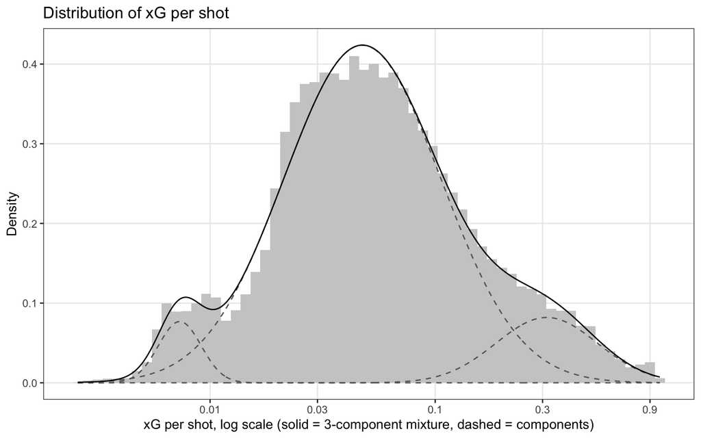

```r
save_fig(plot_shape(shots, stage1), "1-5_shot_quality_mixture", 8, 5)
```

**1.6 Where each kind of shot comes from.** The high-value tail is close-range and central; the long-range cluster is outside the box.

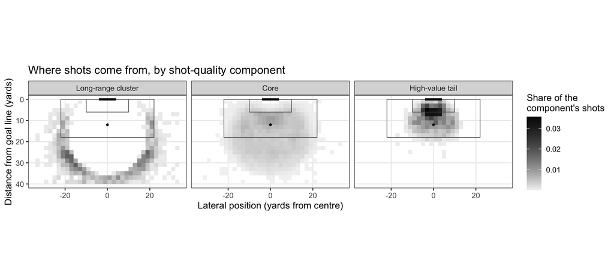

```r
save_fig(plot_shot_map(shots), "1-6_shot_map_by_component", 10, 4.5)
```

```r
show_table(component_profile(shots))
```

| component | n | share | median_xg | median_distance | pct_header | pct_first_time | goal_rate | goals_over_xg |
| --- | --- | --- | --- | --- | --- | --- | --- | --- |
| 1 | 1713 | 0.048 | 0.0070 | 34.5 | 0.004 | 0.159 | 0.009 | 1.33 |
| 2 | 30400 | 0.851 | 0.0475 | 19.3 | 0.182 | 0.318 | 0.063 | 1.01 |
| 3 | 3619 | 0.101 | 0.3500 | 8.9 | 0.156 | 0.528 | 0.416 | 1.04 |

# Stage 2: stints and identification

**2.1 Stint lengths.** Short stints are common, but most minutes are played in long stints with the starting lineups intact, which is the source of the collinearity.

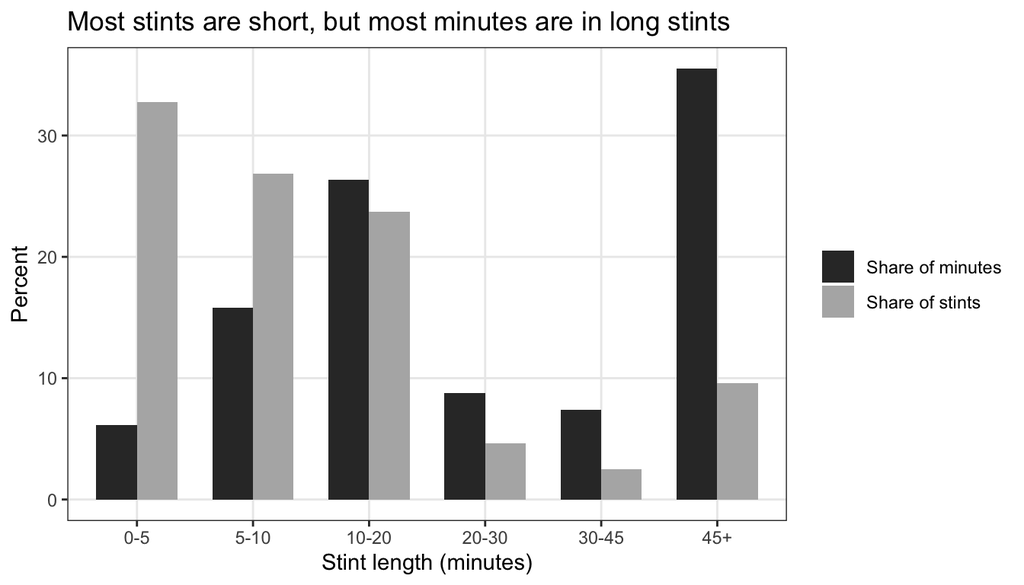

```r
save_fig(plot_stint_lengths(tar_read(stints)), "2-1_stint_lengths", 7, 4)
```

**2.2 Teammate overlap.** Share of the lower-minute player’s time spent on the pitch with the other, for outfield players with 900+ minutes.

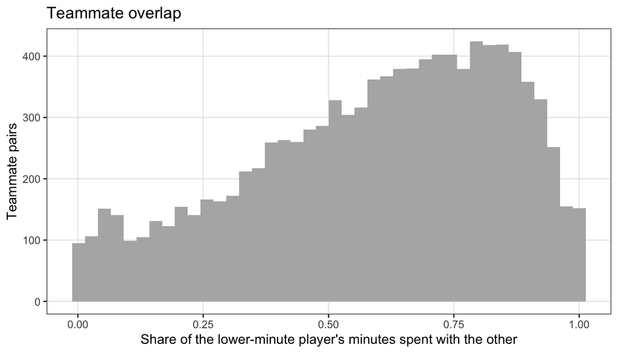

```r
save_fig(plot_overlap(tar_read(overlap)), "2-2_teammate_overlap", 7, 4)
```

**2.3 Precision of player effects.** Most players’ standard errors exceed the entire spread of team attacking effects.

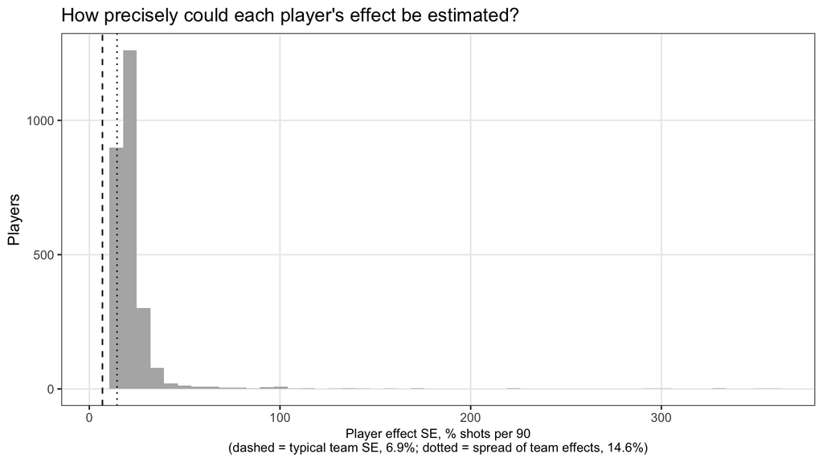

```r
save_fig(plot_player_se(tar_read(precision)), "2-3_player_se", 8, 4.5)
```

**2.4 Game state.** Shot rates by score and time remaining, from the segment table; this is why stage 3b controls for time.

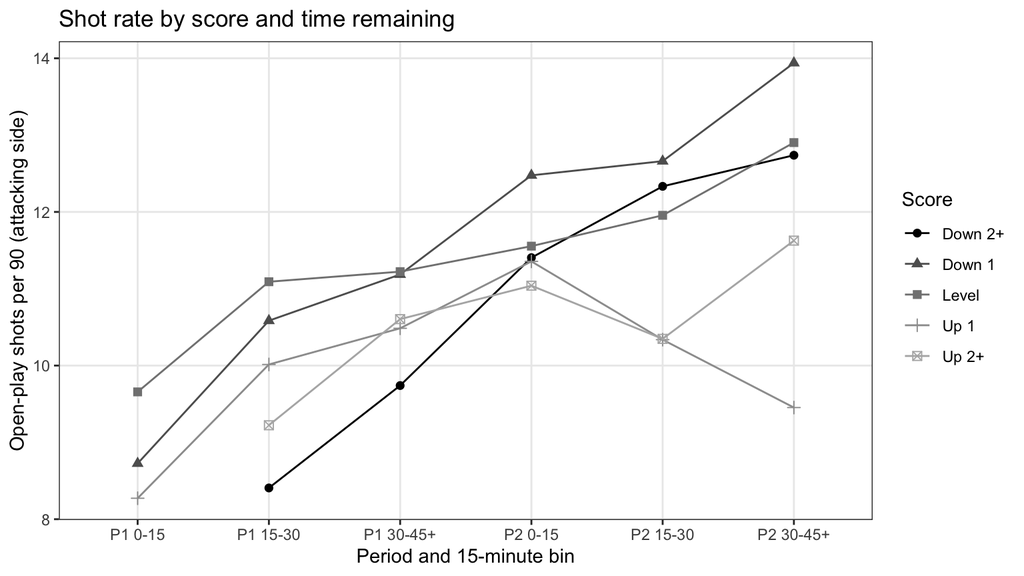

```r
save_fig(plot_game_state(tar_read(segment_table)), "2-4_game_state", 8, 4.5)
```

# Stage 3: player models

**3.1 Held-out deviance by prior SD.** Both player models dip below the team-only line (dotted) at small prior SDs.

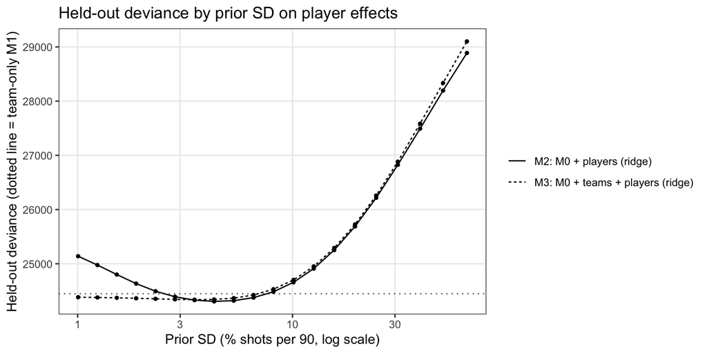

```r
cv3 <- tar_read(cv3)
save_fig(plot_cv_curve(cv3), "3-1_cv_curve", 8, 4)
```

```r
show_table(cv_table(cv3))
```

| Model | Description | Prior SD (% shots per 90) | Held-out deviance | Improvement over M0 | Improvement over M1 | Improvement over M3 |
| --- | --- | --- | --- | --- | --- | --- |
| M0 | League, home, game state | - | 25,721.4 | - | - | - |
| M1 | M0 + teams | - | 24,447.2 | 1,274.2 (SE 113.8) | - | - |
| M2 | M0 + players (ridge) | 4.3 | 24,305.8 | 1,415.6 (SE 66.4) | 141.4 (SE 55.0) | - |
| M3 | M0 + teams + players (ridge) | 3.5 | 24,337.5 | 1,383.9 (SE 95.4) | 109.7 (SE 31.2) | - |

**3.2 Split-half reliability.** M3 fit separately on odd and even matches.

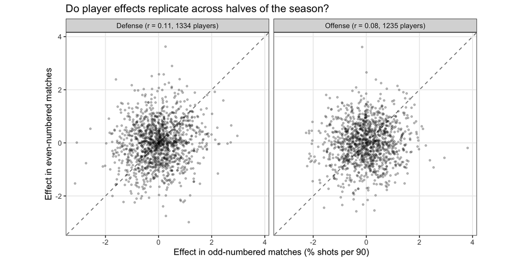

```r
save_fig(plot_split_half(tar_read(split_half3)), "3-2_split_half", 9, 4.5)
```

**3.3 Player effects by position.** Group means shift a little; individual spread is much larger.

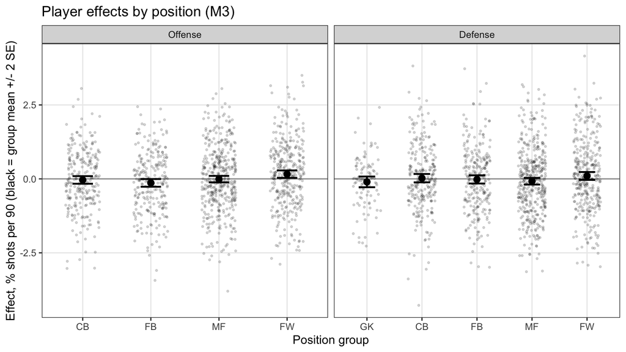

```r
save_fig(plot_effects_by_position(tar_read(effects3), tar_read(positions)),
         "3-3_effects_by_position", 8, 4.5)
```

# Stage 3b: time controls and positional prior

**3b.1 Position effects with and without time controls.** If the filled points sit closer to zero than the open ones, the positional pattern was mostly substitution timing.

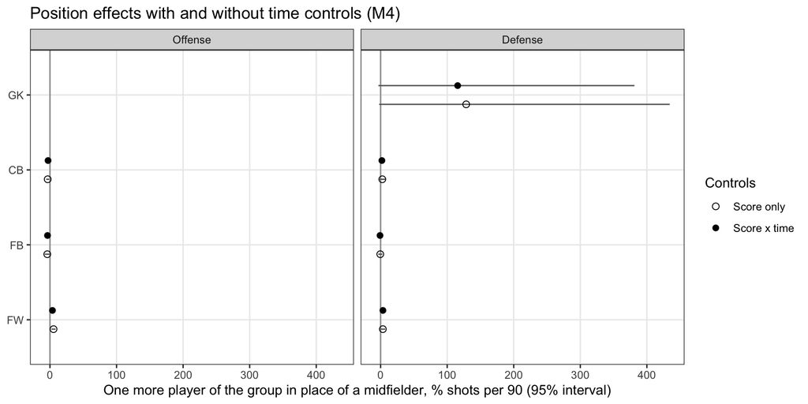

```r
save_fig(plot_position_comparison(tar_read(position_fx)), "3b-1_position_effects", 9, 4.5)
```

**3b.2 Held-out deviance, including the positional prior (M4).**

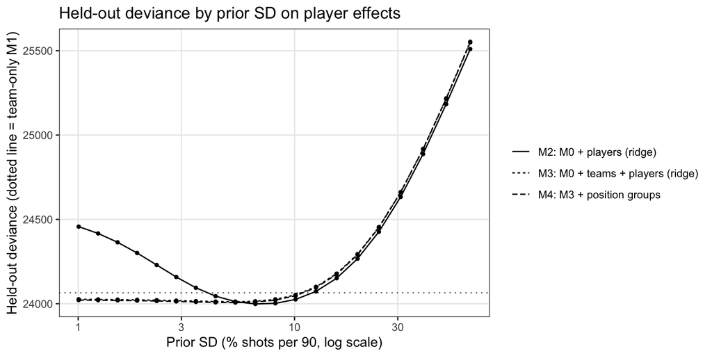

```r
cv3b <- tar_read(cv3b)
save_fig(plot_cv_curve(cv3b), "3b-2_cv_curve", 8, 4)
```

```r
show_table(cv_table(cv3b))
```

| Model | Description | Prior SD (% shots per 90) | Held-out deviance | Improvement over M0 | Improvement over M1 | Improvement over M3 |
| --- | --- | --- | --- | --- | --- | --- |
| M0 | League, home, game state | - | 24,588.0 | - | - | - |
| M1 | M0 + teams | - | 24,064.7 | 523.3 (SE 43.9) | - | - |
| M2 | M0 + players (ridge) | 6.6 | 23,998.7 | 589.3 (SE 30.2) | 66.1 (SE 22.7) | - |
| M3 | M0 + teams + players (ridge) | 5.3 | 24,011.7 | 576.3 (SE 39.5) | 53.0 (SE 15.5) | - |
| M4 | M3 + position groups | 5.3 | 24,006.9 | 581.1 (SE 38.0) | 57.8 (SE 21.8) | 4.8 (SE 10.8) |